# PW3 Logistic Regression

IOS1 - Machine Learning - TD3/Grp 7 - Maxime BOURGEOIS/Thibault BUART/Alexandre BLANCHET/Victor CANAL/Jacques BUDIN

02/10/2020

```r
Social_data <- read.csv("Social_Network_Ads.csv", sep=",")
```

2. Explore and Describe the dataset (you can use str() and summary() functions, you can calculate and visualize the correlations, show some histograms, scatterplots, pie charts, etc..).

```r
str(Social_data)
```

```
## 'data.frame':    400 obs. of  5 variables:
##  $ User.ID        : int  15624510 15810944 15668575 15603246 15804002 15728773 15598044 15694829 15600575 15727311 ...
##  $ Gender         : Factor w/ 2 levels "Female","Male": 2 2 1 1 2 2 1 1 2 1 ...
##  $ Age            : num  19 35 26 27 19 27 27 32 25 35 ...
##  $ EstimatedSalary: num  19000 20000 43000 57000 76000 58000 84000 150000 33000 65000 ...
##  $ Purchased      : int  0 0 0 0 0 0 0 1 0 0 ...
```

```r
summary(Social_data)
```

```
##     User.ID            Gender         Age        EstimatedSalary
##  Min.   :15566689   Female:204   Min.   :18.00   Min.   : 15000
##  1st Qu.:15626764   Male  :196   1st Qu.:29.75   1st Qu.: 43000
##  Median :15694342                Median :37.00   Median : 70000
##  Mean   :15691540                Mean   :37.66   Mean   : 69743
##  3rd Qu.:15750363                3rd Qu.:46.00   3rd Qu.: 88000
##  Max.   :15815236                Max.   :60.00   Max.   :150000
##    Purchased
##  Min.   :0.0000
##  1st Qu.:0.0000
##  Median :0.0000
##  Mean   :0.3575
##  3rd Qu.:1.0000
##  Max.   :1.0000
```

```r
Social_data$Purchased
```

```
##   [1] 0 0 0 0 0 0 0 1 0 0 0 0 0 0 0 0 1 1 1 1 1 1 1 1 1 1 1 1 0 0 0 1 0 0 0 0 0
##  [38] 0 0 0 0 0 0 0 0 0 0 0 1 0 0 0 0 0 0 0 0 0 0 0 0 0 0 1 0 0 0 0 0 0 0 0 0 0
##  [75] 0 1 0 0 0 0 0 0 0 0 0 1 0 0 0 0 0 0 0 0 0 0 0 1 0 0 0 0 0 1 0 0 0 0 0 0 0
## [112] 0 0 0 0 0 0 0 0 0 0 0 0 0 0 0 0 0 0 0 0 0 0 0 0 0 0 1 0 0 0 0 0 0 0 0 1 0
## [149] 0 0 0 0 0 0 0 0 0 0 0 1 1 0 0 0 0 0 0 0 1 0 0 0 0 0 0 0 0 0 0 0 0 0 1 0 0
## [186] 0 0 0 0 0 0 0 0 0 0 0 0 0 0 0 0 0 1 0 1 0 1 0 1 0 1 1 0 0 0 1 0 0 0 1 0 1
## [223] 1 1 0 0 1 1 0 1 1 0 1 1 0 1 0 0 0 1 1 0 1 1 0 1 0 1 0 1 0 0 1 1 0 1 0 0 1
## [260] 1 0 1 1 0 1 1 0 0 1 0 0 1 1 1 1 1 0 1 1 1 1 0 1 1 0 1 0 1 0 1 1 1 1 0 0 0
## [297] 1 1 0 1 1 1 1 1 0 0 0 1 1 0 0 1 0 1 0 1 1 0 1 0 1 1 0 1 1 0 0 0 1 1 0 1 0
## [334] 0 1 0 1 0 0 1 1 0 0 1 1 0 1 1 0 0 1 0 1 0 1 1 1 0 1 0 1 1 1 0 1 1 1 1 0 1
## [371] 1 1 0 1 0 1 0 0 1 1 0 1 1 1 1 1 1 0 1 1 1 1 1 1 0 1 1 1 0 1
```

there are 5 variables:

User ID = integer allowing to identify user

Gender = Factor variable Male or Female

Age = age of users

EstimatedSalary = amout of estimated salary of users

Purchased = 0 or 1 => yes or no

We will consider the variables Age and EstimatedSalary as input variables (features) to see the correlations between them and the decision of the user to buy (or not) the product.

3. Now we are going to split the dataset into training set and test set. Last week we did it manually. From now on we will split it randomly, you can use this code (after undestanding it of course):

```r
library(caTools) # install it first in the console
set.seed(123)
# we use the function set.seed() with the same seed number
# to randomly generate the same values, you already know that right?
#and you know why we want to generate the same values, am I wrong?
split = sample.split(Social_data$Purchased, SplitRatio = 0.75)
# here we chose the SplitRatio to 75% of the dataset,
# and 25% for the test set.
training_set = subset(Social_data, split == TRUE)
# we use subset to split the dataset
test_set = subset(Social_data, split == FALSE)


cor(Social_data$Age, Social_data$EstimatedSalary)
```

```
## [1] 0.155238
```

```r
cor.test(Social_data$Age, Social_data$EstimatedSalary)
```

```
##
##  Pearson's product-moment correlation
##
## data:  Social_data$Age and Social_data$EstimatedSalary
## t = 3.135, df = 398, p-value = 0.001846
## alternative hypothesis: true correlation is not equal to 0
## 95 percent confidence interval:
##  0.05807021 0.24949213
## sample estimates:
##      cor
## 0.155238
```

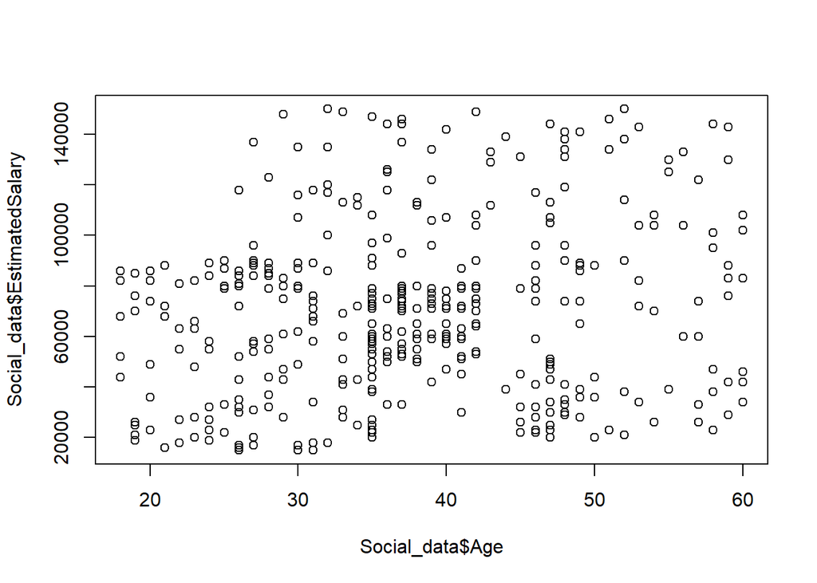

```r
plot(Social_data$Age, Social_data$EstimatedSalary)
```

That’s why we have to be careful about the interaction between input variables

4. Scale the input variables in both training set and test set. Do you know what is scaling? Explain it one sentence.

```r
training_set[c(3,4)]
```

```
##     Age EstimatedSalary
## 1    19           19000
## 3    26           43000
## 6    27           58000
## 7    27           84000
## 8    32          150000
## 10   35           65000
## 11   26           80000
## 13   20           86000
## 14   32           18000
## 15   18           82000
## 16   29           80000
## 17   47           25000
## 21   45           22000
## 23   48           41000
```

[output cut: 286 more lines]

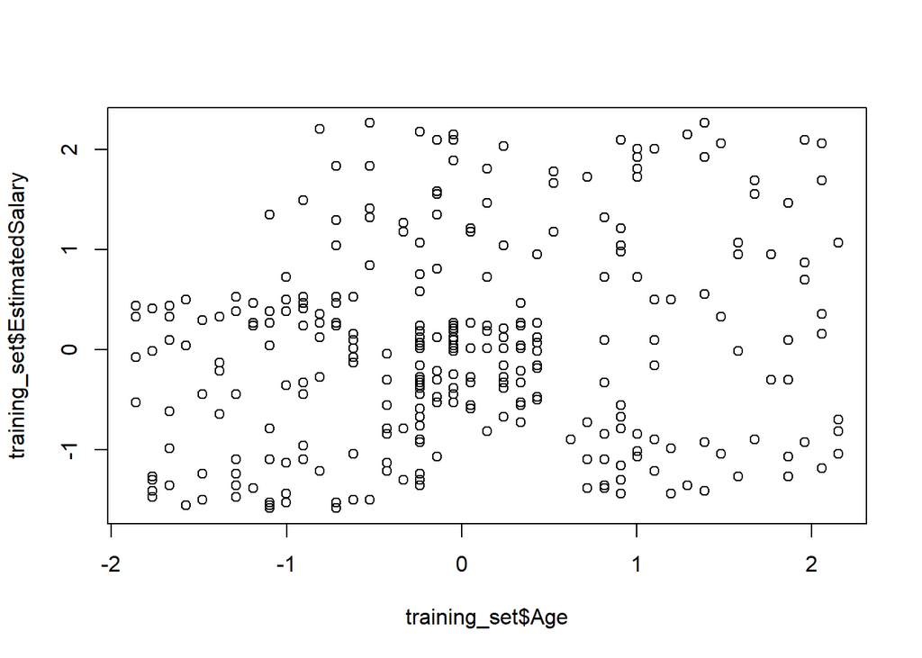

```r
training_set[c(3,4)] = scale(training_set[c(3,4)])

test_set[c(3,4)] = scale(test_set[c(3,4)])


plot(training_set$Age, training_set$EstimatedSalary)
```

Scale function allow you to reshape the scale of variables, here age and salary.

Why ?

- Center the columns of a numeric matrix, in our example the two inputs variables are very distant so it is difficult to represent graphically
- When you create a new model it’s necessary to manipulate low number. Scale don’t change the results and allow to optimize complexity computation.
5. Now fit a simple logistic regression model of Purchased in function of Age.

```r
logisticModel1 <- glm(Purchased ~ Age, family = "binomial", data=training_set)
summary(logisticModel1)
```

```
##
## Call:
## glm(formula = Purchased ~ Age, family = "binomial", data = training_set)
##
## Deviance Residuals:
##     Min       1Q   Median       3Q      Max
## -2.5341  -0.6641  -0.2950   0.5437   2.4392
##
## Coefficients:
##             Estimate Std. Error z value Pr(>|z|)
## (Intercept)  -0.9299     0.1672  -5.562 2.67e-08 ***
## Age           1.9913     0.2342   8.502  < 2e-16 ***
## ---
## Signif. codes:  0 '***' 0.001 '**' 0.01 '*' 0.05 '.' 0.1 ' ' 1
##
## (Dispersion parameter for binomial family taken to be 1)
##
##     Null deviance: 390.89  on 299  degrees of freedom
## Residual deviance: 252.11  on 298  degrees of freedom
## AIC: 256.11
##
## Number of Fisher Scoring iterations: 5
```

6. As you saw in the Logistic Regression chapter and in the previous question, we choose argument family to be binomial when we use the function glm. Explain why!

Logistic regression is a generalized linear model where the variable to predict is binary.

So it follows Bernoulli’s law, and Bernoulli is an exception of Binomial with n-1.

7. Write in an equation the model you obtained in question 5? (Read the following note concerning this question).

Intercept = beta0 = -0.9299

Age = beta1 = 1.9913

Our linear model :

z = beta0+beta1*x

Our logistic function :

p(x) = exp(Z)/(1 + exp(Z))

p(x) = exp(beta0+beta1*x) / (1 + exp(beta0+beta1*x))

p(x=Age) is the probability of sucess of Purchase. Result between 0 and 1.

8. Is the feature Age significant to the model? Justify your answer.

We have beta1 = 1.9913 and it’s p-value < 2e-16, that’s why Age is significant.

9. What is the value of AIC of the model?

```r
AIC(logisticModel1)
```

```
## [1] 256.109
```

10. Plot Purchased in function of Age and add the curve of the obtained logistic regression model.

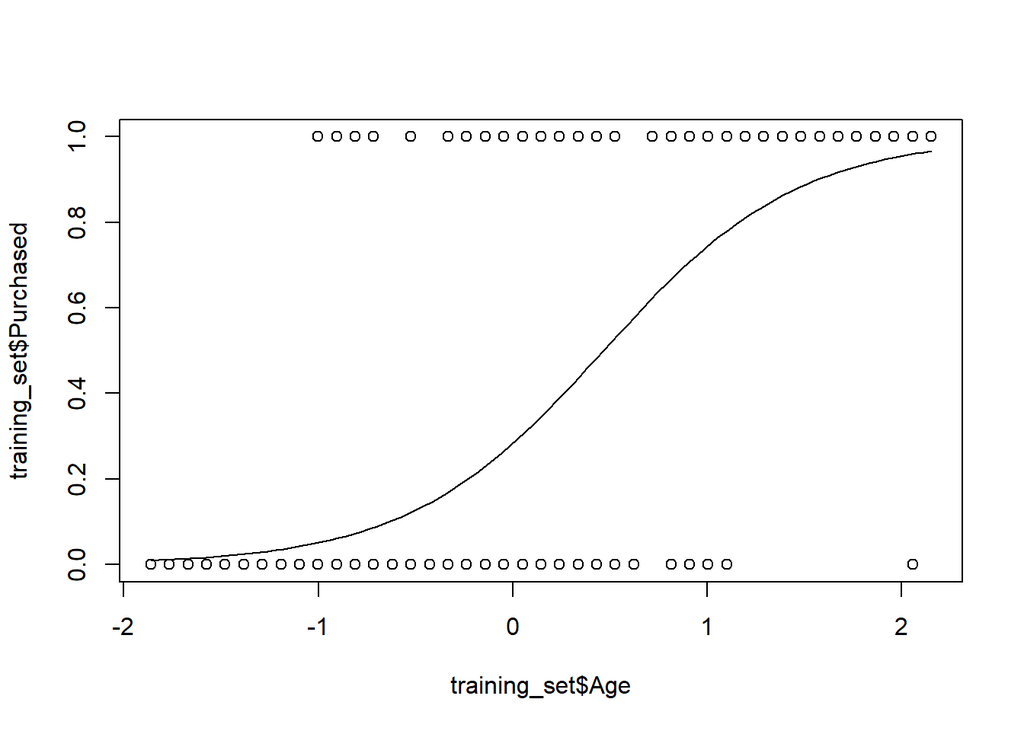

```r
plot(training_set$Age, training_set$Purchased)


beta0 = -0.9299
beta1 =  1.9913



p <- function(x){
  exp(beta0+beta1*x) / (1 + exp(beta0+beta1*x))
  }


x <- training_set$Age

y = predict(logisticModel1, type = "response")



curve(p(x), add=T)
```

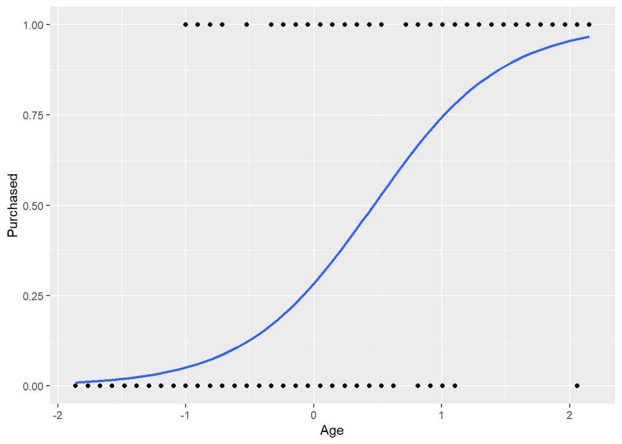

```r
#install.packages("ggplot2")
library(ggplot2)
ggplot(training_set, aes(x=Age, y=Purchased)) +
  geom_point() +
  stat_smooth(method="glm", method.args=list(family="binomial"), se=FALSE)
```

11. Now let us take another feature into account in the model. Fit a logistic regression model of purchasing the product in function of the age of a user and its salary.

```r
logisticModel2 = glm(Purchased ~ Age + EstimatedSalary, family="binomial", data = training_set)
summary(logisticModel2)
```

```
##
## Call:
## glm(formula = Purchased ~ Age + EstimatedSalary, family = "binomial",
##     data = training_set)
##
## Deviance Residuals:
##     Min       1Q   Median       3Q      Max
## -3.0753  -0.5235  -0.1161   0.3224   2.3977
##
## Coefficients:
##                 Estimate Std. Error z value Pr(>|z|)
## (Intercept)      -1.1923     0.2018  -5.908 3.47e-09 ***
## Age               2.6324     0.3461   7.606 2.83e-14 ***
## EstimatedSalary   1.3947     0.2326   5.996 2.03e-09 ***
## ---
## Signif. codes:  0 '***' 0.001 '**' 0.01 '*' 0.05 '.' 0.1 ' ' 1
##
## (Dispersion parameter for binomial family taken to be 1)
##
##     Null deviance: 390.89  on 299  degrees of freedom
## Residual deviance: 199.78  on 297  degrees of freedom
## AIC: 205.78
##
## Number of Fisher Scoring iterations: 6
```

12. Are the predictors significant to the new model?

Yes the coefficient are significant because all p-value are lower than 0.05.

13. Do we obtain a better model by adding the estimated salary?

The new AIC is lower so it’s a better model thant the last one.

14. Predictions: On the test set, predict the probability of purchasing the product by the users using the obtained model.

```r
new_test = data.frame(test_set)
new_test[c(6)] = predict(logisticModel2, newdata=test_set[c(3,4)], type="response")
names(new_test)[6] = "Proba estim. of sucess"
new_test
```

```
##      User.ID Gender         Age EstimatedSalary Purchased
## 2   15810944   Male -0.30419063     -1.51354339         0
## 4   15603246 Female -1.05994374     -0.32456026         0
## 5   15804002   Male -1.81569686      0.28599864         0
## 9   15600575   Male -1.24888202     -1.09579256         0
## 12  15606274 Female -1.15441288     -0.48523366         0
## 18  15617482   Male  0.64050076     -1.32073531         1
## 19  15704583   Male  0.73496990     -1.25646596         1
## 20  15621083 Female  0.92390818     -1.22433128         1
## 22  15736760 Female  0.82943904     -0.58163769         1
## 29  15744529   Male -0.87100546     -0.77444577         0
## 32  15729054 Female -1.05994374      2.24621408         1
## 34  15776733 Female -0.96547460     -0.74231109         0
## 35  15724858   Male -1.05994374      0.73588415         0
## 38  15689425   Male -0.77653633     -0.58163769         0
```

[output cut: 187 more lines]

15. Take a look on your predicted values for the variable Purchased. We predicted theprobability that the user will purchase the product right? Now in order to compare your resultswith the real answers, transform the predicted values to 0 or 1 (1 if >0.5).

```r
new_test[6] = ifelse(new_test[6] > 0.5, 1, 0)
```

16. Now in order to evaluate the model and its predictions, compute the confusion matrix.What do you obtain ?

```r
mat = table(new_test[c(5, 6)])
mat
```

```
##          Proba estim. of sucess
## Purchased  0  1
##         0 57  7
##         1 10 26
```

for the 0 value there are 57 true values

for the 1 value there are 26 true values

17. Calculate the accuracy, specificity, sensitivity and the precision of the model.

```r
library(ROCR)
acc = (57 + 26) / sum(mat)
acc
```

```
## [1] 0.83
```

```r
spec = 7 / 100
sens = 26 / 100
precision = 26 / 33
precision
```

```
## [1] 0.7878788
```

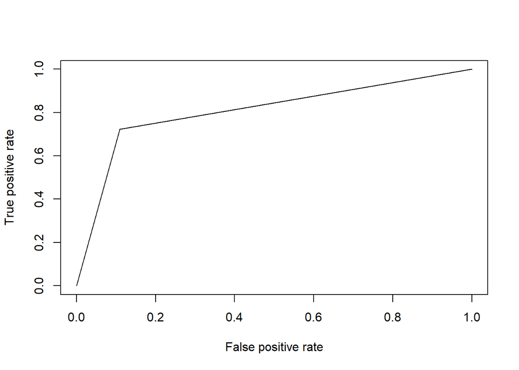

```r
pred = prediction(new_test[6], new_test[5])
perf = performance(pred, measure = "auc")
perf2 = performance(pred, "tpr", "fpr")
plot(perf2)
```